# DS 6306 Final Project 2

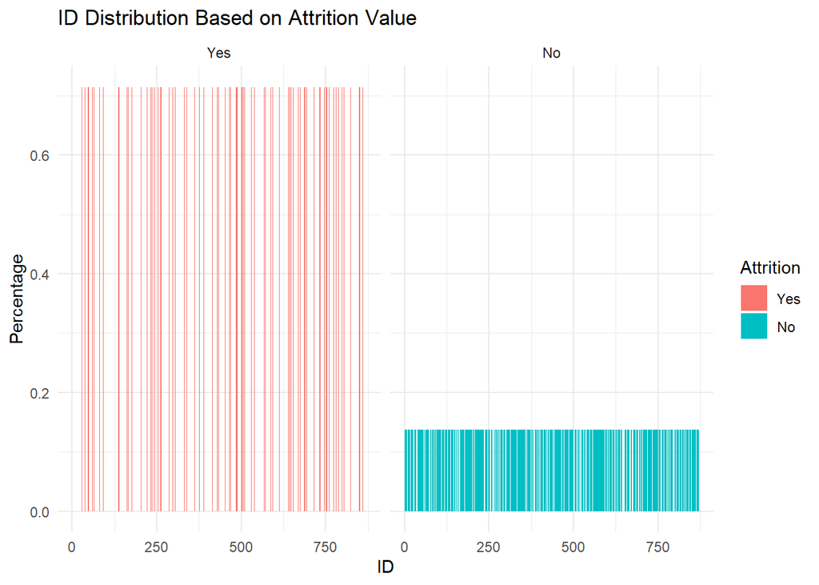

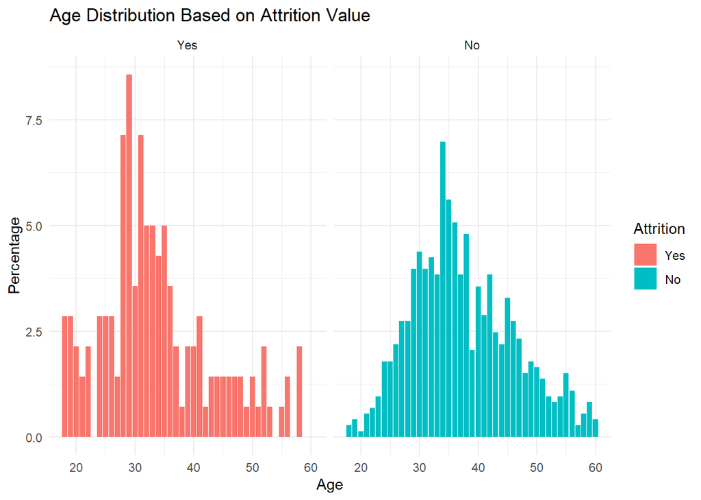

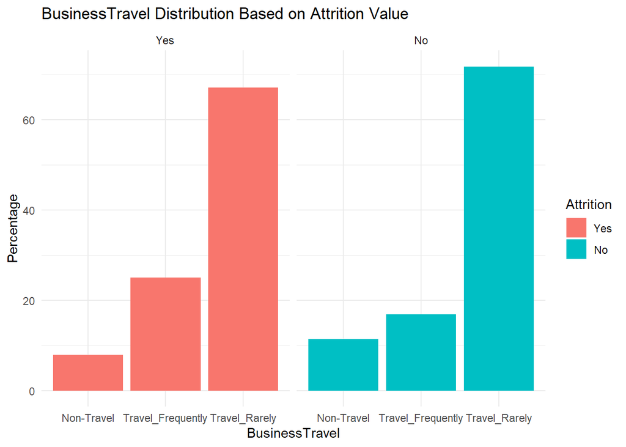

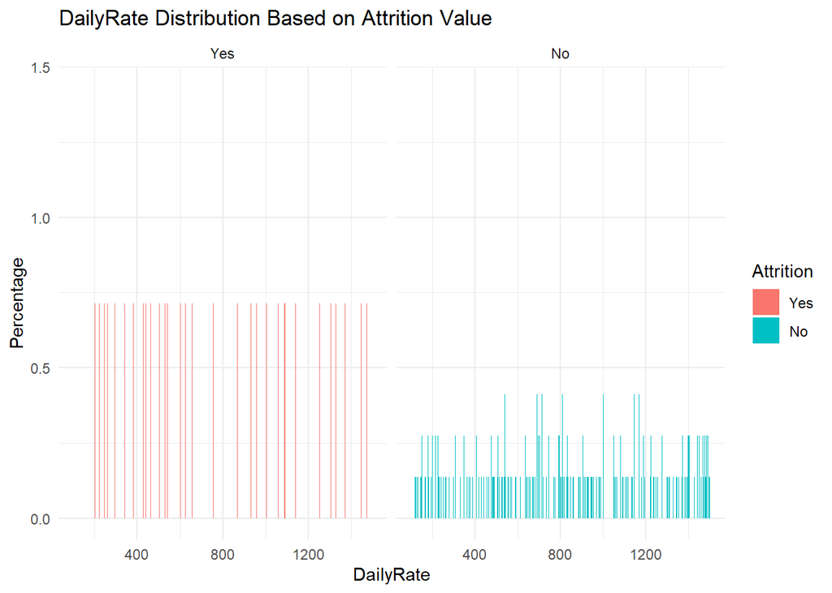

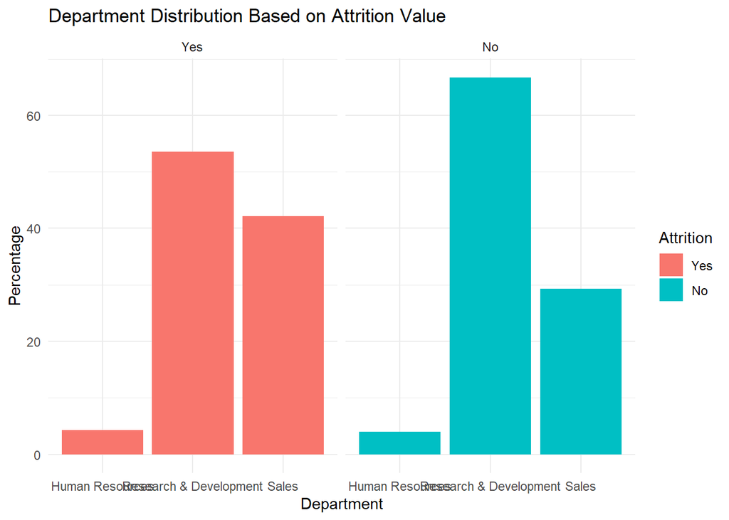

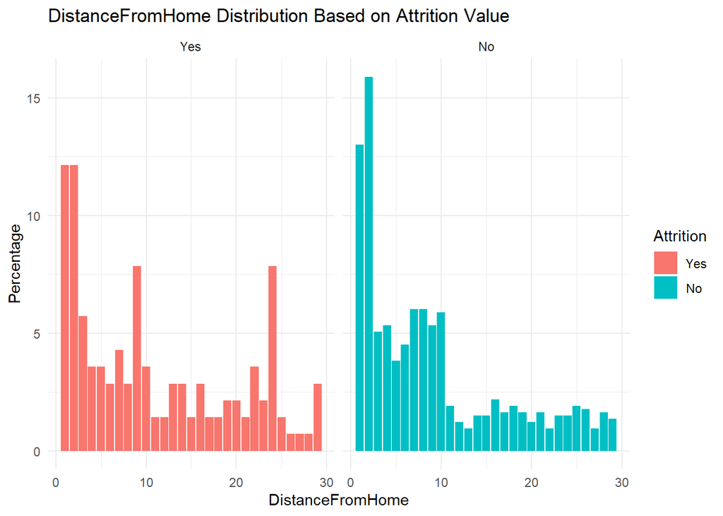

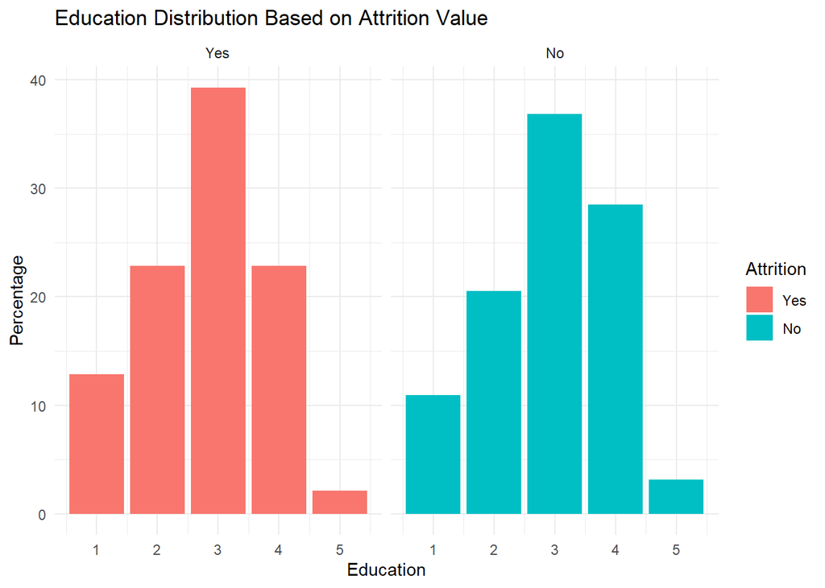

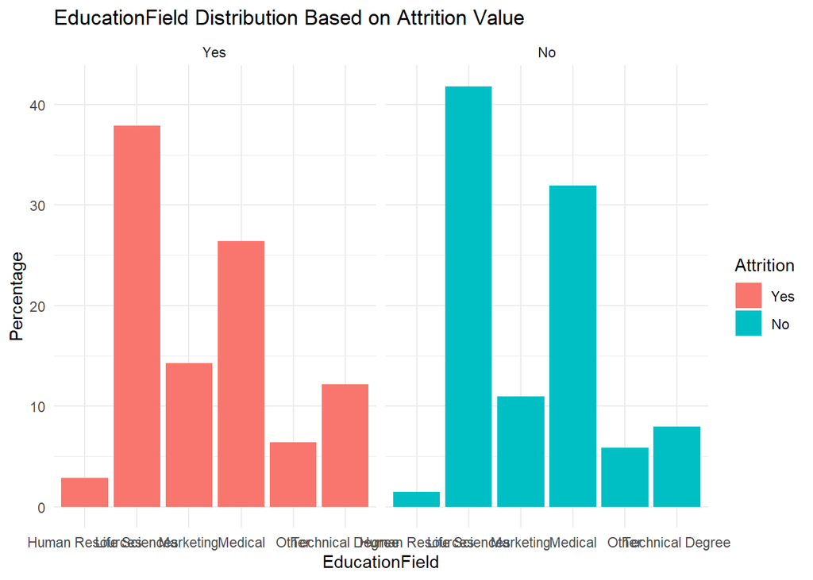

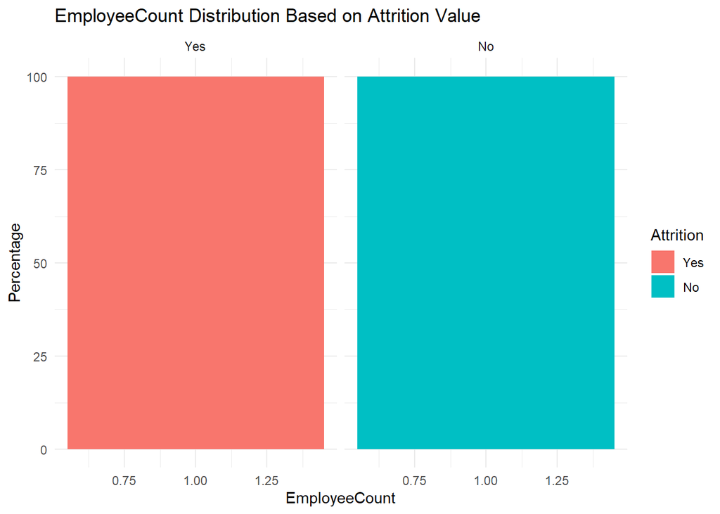

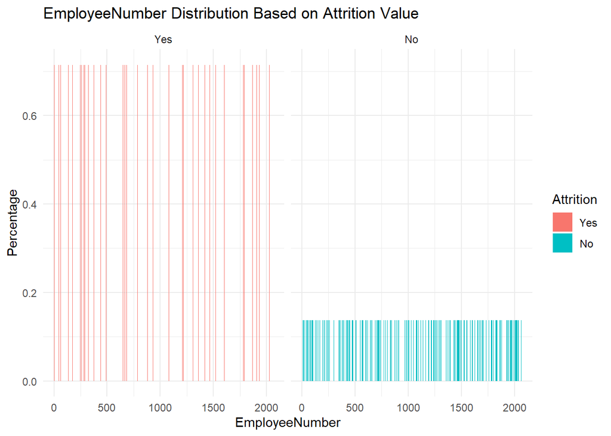

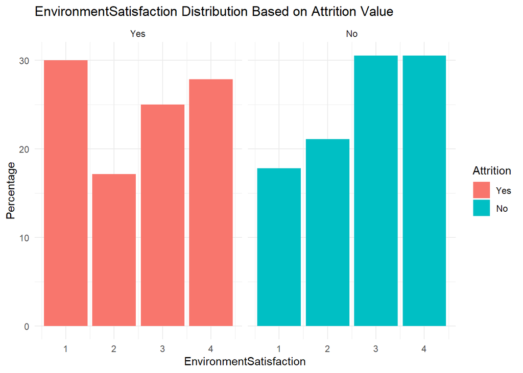

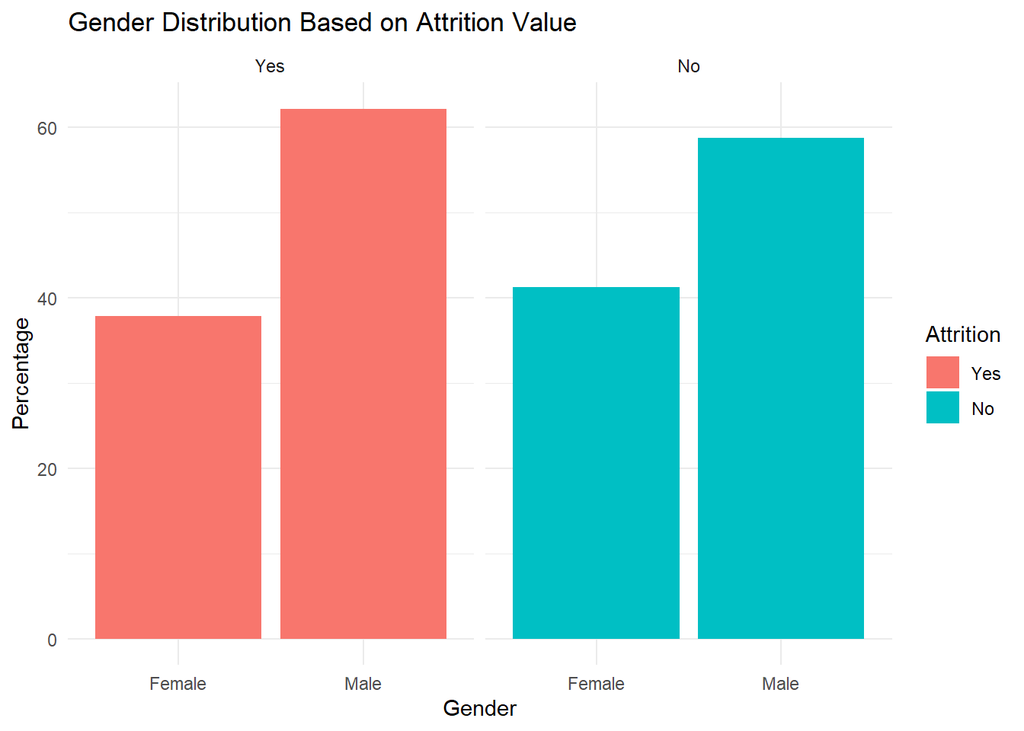

[23 more figures not shown]

```r
# Since the variables are a lot, and i plan on saving time, I plan using a for loop to iterate through the variables and plot their bar plots to visualize their EDA

# Iterate through the dataset and execute the plot command
for (Variable in names(Talent_Train)){
  # Check if the column is numeric
  if  (!(Variable == "Attrition")) { #(!is.numeric(Talent_Train[[Variable]]) &&

    # Construct the bunch of commands with the current variable

  command <- paste0(
    "summary <- Talent_Train %>% \n",
    "group_by(", Variable, ", Attrition) %>% \n",
    "summarize(count=n(), .groups = 'drop') \n",
    "summary$perc <- 0 \n",
    "summary$perc[summary$Attrition == 'No'] <- summary$count[summary$Attrition == 'No'] / nrow(Talent_Train[Talent_Train$Attrition == 'No',]) * 100 \n",
    "summary$perc[summary$Attrition == 'Yes'] <- summary$count[summary$Attrition == 'Yes'] / nrow(Talent_Train[Talent_Train$Attrition == 'Yes',]) * 100 \n",
    "summary %>% ggplot(aes(x=", Variable, ",y=perc,fill=Attrition)) + geom_bar(stat='identity') + facet_wrap(~Attrition) + \n",
    "ylab('Percentage') + xlab('", Variable, "') + ggtitle('", Variable, " Distribution Based on Attrition Value') + theme_minimal() \n"
  )

    # Execute the command
    plot <- eval(parse(text = command))

    print(plot)
  }
}
```

- There seems to be a high turnover rate among employees with zero stock options level. - There is a higher level of Employee turnover Rate among the employees in Job Level - There is a similar distribution overall between the monthly salary and employees that didn’t leave in terms of JobLevel. - There are similarities among the yes and no distributions. - There seems to be high turnover rate among employees with 10 years of in the company. - There seems to be a low turn over rate among employees with 1-3 years in the company. - There are similar distribution among the monthly income and the no attrition rates.

#### LOOKING AT THE PVALUE DISTRIBUTIONS FOR THE ATTRITION

```r
model <-glm(Attrition ~ ., data = Talent_Train, family="binomial")

# Extract variable names
variable_names <- rownames(summary(model)$coefficients)

# getting the  p-values from the model3
p_values <- summary(model)$coefficients[, 4]  # Assuming p-values are in the 4th column of the summary table
p_values <- data.frame(p_values)$p_values

df <- data.frame(variable_names, p_values) #combining the pvalues and variable names into a dataframe

df <- df[!df$p_value == 0 , ] #removing varaiables with pvalue = 0
df$p_values <- log(df$p_values)  * -1

# Rank p-values in the dataset from max to min
df$rank <- rank(-df$p_value)

sorted_df <- df[order(df$rank), ]

sorted_df
```

```
##                      variable_names    p_values rank
## 36                      OverTimeYes 31.74224176    1
## 20                   JobInvolvement 12.37046792    2
## 30                  JobSatisfaction 11.63504785    3
## 35               NumCompaniesWorked 11.60462375    4
## 46          YearsSinceLastPromotion  9.97531527    5
## 32              MaritalStatusSingle  7.58076069    6
## 9                  DistanceFromHome  7.21448298    7
## 43                  WorkLifeBalance  7.06700978    8
## 4   BusinessTravelTravel_Frequently  6.20191210    9
## 17          EnvironmentSatisfaction  6.06532036   10
## 42            TrainingTimesLastYear  5.17313554   11
## 47             YearsWithCurrManager  4.37140068   12
## 41                TotalWorkingYears  4.35937156   13
## 39         RelationshipSatisfaction  4.24141087   14
```

[output cut: 33 more lines]

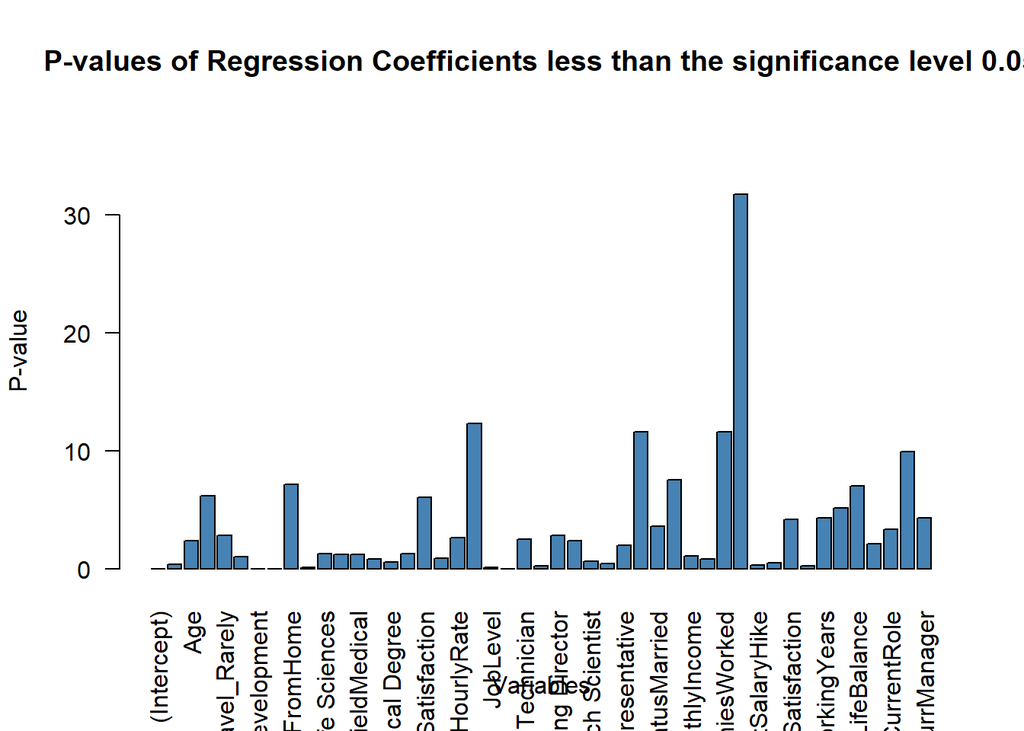

```r
barplot(df$p_values,
        main = "P-values of Regression Coefficients less than the significance level 0.05",
        xlab = "Variables",
        ylab = "P-value",
        names.arg = df$variable_names,
        las = 2,  # Rotate x-axis labels vertically for better readability
        col = "steelblue",  # Set color of bars
        ylim = c(exp(0.05) * -1, max(sorted_df$p_values) * 1.2)  # Set ylim from the significance level to the max p-values

)
```

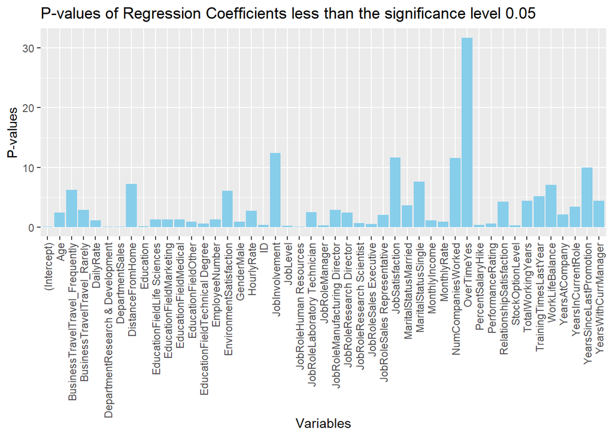

```r
library(ggplot2)
ggplot(sorted_df,aes(variable_names,p_values, fill = ifelse(p_values > (exp(0.05) * -1), "Positive", "Negative"))) + #filtering just the highly significant p-values
  geom_bar(stat="identity", fill = "skyblue") +
  #geom_text(aes(label = variable_names), vjust = -0.5) +  # Add text labels on top of bars
  scale_fill_manual(values = c("Positive" = "skyblue", "Negative" = "salmon")) +
  labs(x = "Variables", y = "P-values", title = "P-values of Regression Coefficients less than the significance level 0.05") +
  theme(axis.text.x = element_text(angle = 90, vjust = 0.5, hjust=1))  # Rotate x-axis labels for better readability
```

From the plot above, we can see that the top 5 highly significant values with respect to the response variable Attrition in terms of its relative most significant to least significant variables are OverTime, JobInvolvement, JobSatisfaction, NumCompaniesWorked, YearsSinceLastPromotion

#### USING FORWARD SELECTION TO GET THE VARIABLE WITH THE BEST AUC METRIC FOR THE PREDICTION MODEL ON THE ATTRITION VARIABLE I pLAN TO USE ONLY NUMERIC VARIABLES FOR KNN

I plan on using the same strategy as for our regression model. This time i shall look at the Area under the curve (AUROC), which represents of the trade-off between the true positive rate (sensitivity) and the false positive rate (1 - specificity) as the classification threshold is varied. Ill be looking for the variables that provides the maximum auroc using a general logistiic model

#### GETTING THE 1ST VARIABLE:

Im looking for the perfect (Attrition ~ dependent variable) combination to get the maximum auroc score

```r
Talent_Clean <- Talent_Train %>% select(Age, DailyRate, DistanceFromHome, Education, EmployeeCount, EmployeeNumber, EnvironmentSatisfaction, HourlyRate, JobInvolvement, JobLevel, JobSatisfaction, MonthlyIncome, MonthlyRate, NumCompaniesWorked, PercentSalaryHike, PerformanceRating, RelationshipSatisfaction, StandardHours, StockOptionLevel, TotalWorkingYears, TrainingTimesLastYear, WorkLifeBalance, YearsAtCompany, YearsInCurrentRole, YearsSinceLastPromotion, YearsWithCurrManager, Over18_binary, Attrition) #selecting only numeric variables

# Forward Selection # 1
set.seed(21)
vars <- names(Talent_Clean)
vars <- vars[vars!="Attrition"] #iterating thru variables that are not "Attrition"
vars <- vars[vars != "MonthlyIncome"] #iterating thru variables that are not "MonthlyIncome"
num_vars <- length(vars)
var_aucs <- data.frame("vars" = vars)
num_folds <- 10
for (j in 1:num_vars) {
  var <- vars[j]
  #print(var)
  folds <- createFolds(Talent_Clean$Attrition, k = num_folds)
  auc_scores <- numeric(num_folds)
  for (i in 1:num_folds) {
    train_indices <- unlist(folds[-i])
    test_indices <- unlist(folds[i])
    train <- Talent_Clean[train_indices, ]
    test <- Talent_Clean[test_indices, ]
    form <- as.formula(paste("Attrition ~ ",var,sep=""))
    model <- glm(form, data = train, family = "binomial")
    predictions <- predict(model, newdata = test, type = "response")
    roc <- roc(response=test$Attrition,predictor=predictions,levels=c("No", "Yes"),direction = ">")
    auc_scores[i] <- auc(roc) #calculating the area under the curve
  }
  var_aucs$auc[var_aucs$var == var] <- mean(auc_scores)
}

max_auc = max(var_aucs$auc) #finding the max_auc
max_auc_variable <- var_aucs$vars[which.max(var_aucs$auc)]

cat("optimum Variable is ", max_auc_variable, " with a maximum auc of ", max_auc)
```

```
## optimum Variable is  TotalWorkingYears  with a maximum auc of  0.6523973
```

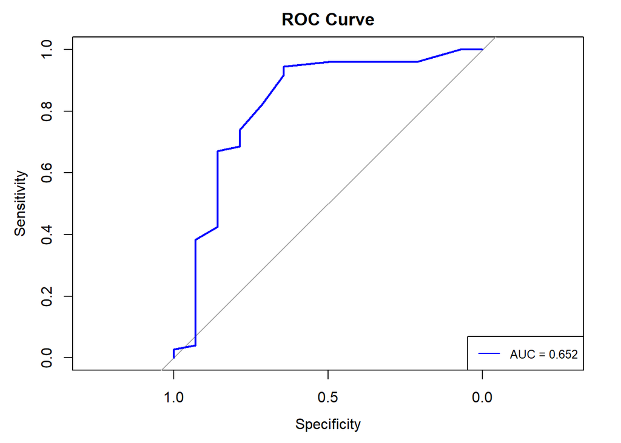

```r
#Plotting an auc curve
form <- Attrition ~ TotalWorkingYears
model <- glm(form, data = train, family = "binomial")
predictions <- predict(model, newdata = test, type = "response")
roc <- roc(test$Attrition, predictions)
plot(roc, main = "ROC Curve", col = "blue", lwd = 2)
# Add AUC to the plot
legend("bottomright", legend = paste("AUC =", round(max_auc, 3)), col = "blue", lty = 1, cex = 0.8)
```

optimum Variable is TotalWorkingYears with a maximum auc of 0.6523973

#### GETTIONG THE SECOND VARIABLE

Next ill look for the optimumm variable to add to our classification model (Attrition ~ TotalWorkingYears) in order to provide the maximum auc score

```r
# Forward Selection # 1
set.seed(21)
vars <- names(Talent_Clean)
vars <- vars[vars!="Attrition"] #iterating thru variables that are not "Attrition"
vars <- vars[vars != "MonthlyIncome"] #iterating thru variables that are not "MonthlyIncome"
vars <- vars[vars != "TotalWorkingYears "] #iterating thru variables that are not "TotalWorkingYears "
num_vars <- length(vars)
var_aucs <- data.frame("vars" = vars)
num_folds <- 10
numks = 60
for (j in 1:num_vars) {
  var <- vars[j]
  #print(var)
  folds <- createFolds(Talent_Clean$Attrition, k = num_folds)
  auc_scores <- numeric(num_folds)
  for (i in 1:num_folds) {
    train_indices <- unlist(folds[-i])
    test_indices <- unlist(folds[i])
    train <- Talent_Clean[train_indices, ]
    test <- Talent_Clean[test_indices, ]
    form <- as.formula(paste("Attrition ~ TotalWorkingYears  + ",var,sep=""))
    model <- glm(form, data = train, family = "binomial")
    predictions <- predict(model, newdata = test, type = "response")
    roc <- roc(response=test$Attrition,predictor=predictions,levels=c("No", "Yes"),direction = ">")
    auc_scores[i] <- auc(roc) #calculating the area under the curve
  }
  var_aucs$auc[var_aucs$var == var] <- mean(auc_scores)
}

max_auc = max(var_aucs$auc) #finding the max_auc
max_auc_variable <- var_aucs$vars[which.max(var_aucs$auc)]

cat("optimum Variable is ", max_auc_variable, " with a maximum auc of ", max_auc)
```

```
## optimum Variable is  StockOptionLevel  with a maximum auc of  0.6940313
```

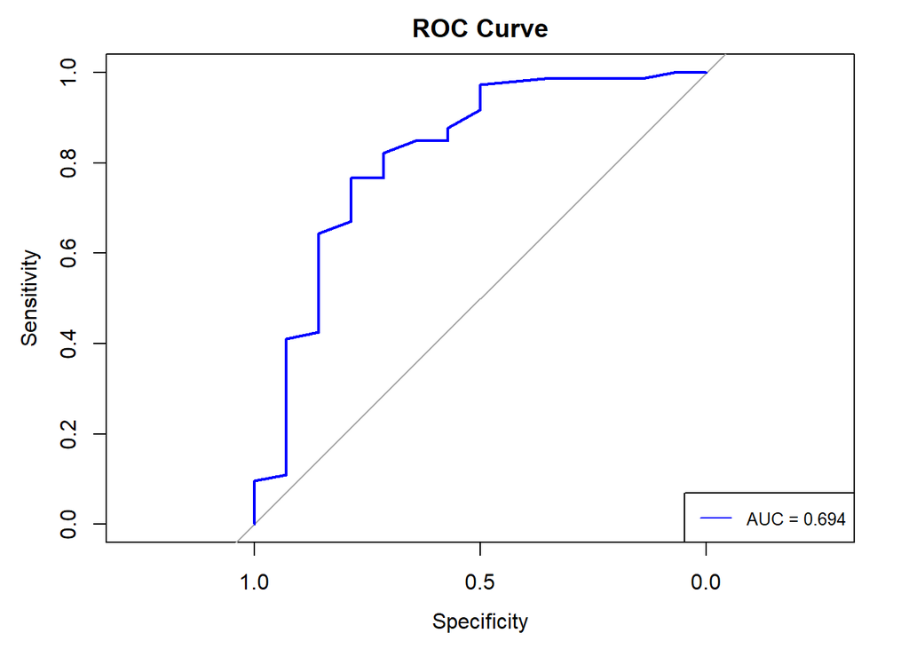

```r
#Plotting an auc curve
form <- Attrition ~ TotalWorkingYears + StockOptionLevel
model <- glm(form, data = train, family = "binomial")
predictions <- predict(model, newdata = test, type = "response")
roc <- roc(test$Attrition, predictions)
plot(roc, main = "ROC Curve", col = "blue", lwd = 2)
# Add AUC to the plot
legend("bottomright", legend = paste("AUC =", round(max_auc, 3)), col = "blue", lty = 1, cex = 0.8)
```

optimum Variable is StockOptionLevel with a maximum auc of 0.6940313

#### GETTIONG THE THIRD VARIABLE

Next ill look for the optimumm variable to add to our classification model (Attrition ~ TotalWorkingYears + StockOptionLevel) in order to provide the maximum auc score

```r
# Forward Selection # 1
set.seed(21)
vars <- names(Talent_Clean)
vars <- vars[vars!="Attrition"] #iterating thru variables that are not "Attrition"
vars <- vars[vars != "MonthlyIncome"] #iterating thru variables that are not "MonthlyIncome"
vars <- vars[vars != "TotalWorkingYears "] #iterating thru variables that are not "TotalWorkingYears "
vars <- vars[vars != "StockOptionLevel"] #iterating thru variables that are not "JobRole"
num_vars <- length(vars)
var_aucs <- data.frame("vars" = vars)
num_folds <- 10
numks = 60
for (j in 1:num_vars) {
  var <- vars[j]
  #print(var)
  folds <- createFolds(Talent_Clean$Attrition, k = num_folds)
  auc_scores <- numeric(num_folds)
  for (i in 1:num_folds) {
    train_indices <- unlist(folds[-i])
    test_indices <- unlist(folds[i])
    train <- Talent_Clean[train_indices, ]
    test <- Talent_Clean[test_indices, ]
    form <- as.formula(paste("Attrition ~ TotalWorkingYears  + StockOptionLevel + ",var,sep=""))
    model <- glm(form, data = train, family = "binomial")
    predictions <- predict(model, newdata = test, type = "response")
    roc <- roc(response=test$Attrition,predictor=predictions,levels=c("No", "Yes"),direction = ">")
    auc_scores[i] <- auc(roc) #calculating the area under the curve
  }
  var_aucs$auc[var_aucs$var == var] <- mean(auc_scores)
}

max_auc = max(var_aucs$auc) #finding the max_auc
max_auc_variable <- var_aucs$vars[which.max(var_aucs$auc)]

cat("optimum Variable is ", max_auc_variable, " with a maximum auc of ", max_auc)
```

```
## optimum Variable is  JobInvolvement  with a maximum auc of  0.7157045
```

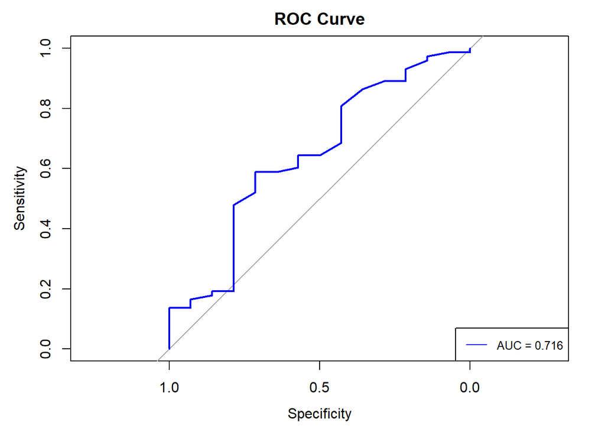

```r
#Plotting an auc curve
form <- Attrition ~ TotalWorkingYears + StockOptionLevel + JobInvolvement
model <- glm(form, data = train, family = "binomial")
predictions <- predict(model, newdata = test, type = "response")
roc <- roc(test$Attrition, predictions)
plot(roc, main = "ROC Curve", col = "blue", lwd = 2)
# Add AUC to the plot
legend("bottomright", legend = paste("AUC =", round(max_auc, 3)), col = "blue", lty = 1, cex = 0.8)
```

optimum Variable is JobInvolvement with a maximum auc of 0.7157045

#### Looking at the Sensitivity & Specificity Metric FOR NB

Next ill be looking at the sensitivity and specificity metric of our classification model using k- Nearest Neigbors (KNN) and Naive Bayes

#### FINDING THE THRESHOLD

```r
set.seed(123)
Talent_Clean <- Talent_Train %>% select(Attrition, TotalWorkingYears, StockOptionLevel, JobInvolvement) #selecting our variables
trainIndices <- sample(seq(1:length(Talent_Clean$Attrition)), round(0.7 * length(Talent_Clean$Attrition)))
train <- Talent_Clean[trainIndices, ]
test <- Talent_Clean[-trainIndices, ]

train$Attrition <-factor(train$Attrition, levels=c('Yes','No')) #factoring the response variable
test$Attrition <-factor(test$Attrition, levels=c('Yes','No')) #factoring the response variable

naive_bayes_model <- naiveBayes(Attrition ~ TotalWorkingYears  + StockOptionLevel + JobInvolvement, data = train)

# Make predictions on the test set
predictions <- predict(naive_bayes_model, test)

# Evaluate model performance
conf_matrix <- confusionMatrix(predictions, test$Attrition)

# Print the confusion matrix
#print(conf_matrix)

# Adjust label levels for better interpretation
test$Attrition <- relevel(test$Attrition, ref = "No")

# Make predictions with probabilities
predictions_with_probs <- predict(naive_bayes_model, test, type = "raw")

# Get probabilities of the positive class ("Yes")
probs <- predictions_with_probs[, "Yes"]

# Define a new threshold
new_threshold <- 0.5

# Create new labels based on the new threshold
new_labels <- ifelse(probs > new_threshold, "Yes", "No")

# Convert the predicted labels to a factor with the same levels as the actual labels
new_labels_factor <- factor(new_labels, levels = levels(test$Attrition))

# Evaluate model performance with the new threshold
new_conf_matrix <- confusionMatrix(new_labels_factor, test$Attrition)

# Print the confusion matrix with the new threshold
#print(new_conf_matrix)

# Calculate the macro F1 score with the new threshold
macro_f1_new_threshold <- mean(c(new_conf_matrix[4]$byClass["F1"], conf_matrix[4]$byClass["F1"]))

# Print the macro F1 score with the new threshold
print(macro_f1_new_threshold)
```

```
## [1] 0.5725983
```

#### Looking at the Metrics

```r
test$Attrition = relevel(test$Attrition, ref = 'Yes')

# Train a Naive Bayes model
naive_bayes_model <- naiveBayes(Attrition ~ TotalWorkingYears  + StockOptionLevel + JobInvolvement, data = train)

# Get predicted probabilities for the positive class (assuming 'Yes' is the positive class)
predicted_probabilities <- predict(naive_bayes_model, test, type = "raw")[, "Yes"]

# Define threshold
threshold <- macro_f1_new_threshold  # Adjust as needed

# Adjust predictions based on threshold
adjusted_predictions <- ifelse(predicted_probabilities > threshold, "Yes", "No")

# Evaluate model performance
adjusted_predictions <- factor(adjusted_predictions, levels = levels(test$Attrition))

conf_matrix <- confusionMatrix(table(adjusted_predictions, test$Attrition))
print(conf_matrix)
```

```
## Confusion Matrix and Statistics
##
##
## adjusted_predictions Yes  No
##                  Yes   6   3
##                  No   46 206
##
##                Accuracy : 0.8123
##                  95% CI : (0.7595, 0.8578)
##     No Information Rate : 0.8008
##     P-Value [Acc > NIR] : 0.3542
##
##                   Kappa : 0.1465
##
##  Mcnemar's Test P-Value : 1.973e-09
##
##             Sensitivity : 0.11538
##             Specificity : 0.98565
##          Pos Pred Value : 0.66667
##          Neg Pred Value : 0.81746
##              Prevalence : 0.19923
##          Detection Rate : 0.02299
##    Detection Prevalence : 0.03448
##       Balanced Accuracy : 0.55052
##
##        'Positive' Class : Yes
##
```

```r
accuracy_nb <- conf_matrix$overall["Accuracy"]
sensitivity_nb <- conf_matrix$byClass["Sensitivity"]
specificity_nb <- conf_matrix$byClass["Specificity"]
```

#KNN MODEL #### Looking at the Sensitivity & Specificity Metric FOR KNN using undersampling I plan on using undersampling to get our metrics, due to the imbalance between Yes and No attrition rates. I am basically reducing the No dataset, in order to match the Yes dataset, to improve sensitivity.

```r
set.seed(123)
Talent_Clean <- Talent_Train %>% select(Attrition, TotalWorkingYears, StockOptionLevel, JobInvolvement, ID) #selecting our variables
trainIndices <- sample(seq(1:length(Talent_Clean$Attrition)), round(0.7 * length(Talent_Clean$Attrition)))
train <- Talent_Clean[trainIndices, ]
test <- Talent_Clean[-trainIndices, ]

# Sample only a subset of 'No' instances to balance the classes
OnlyNoAttrition <- train %>% filter(Attrition == "No")
numYesAttrition <- sum(train$Attrition == "Yes")
sampled_NoAttrition <- OnlyNoAttrition[sample(seq(1, nrow(OnlyNoAttrition), 1), numYesAttrition),]

# Combine sampled 'No' instances with 'Yes' instances to create a balanced dataset
balanced_data <- rbind(train %>% filter(Attrition == "Yes"), sampled_NoAttrition)

dim(balanced_data)
```

```
## [1] 176   5
```

```r
classifications = knn(balanced_data[,2:4],train[,2:4], balanced_data[,1], prob = TRUE, k = 5) # using the F (original dataset) as the test set

table(classifications,train[,1])
```

```
##
## classifications Yes  No
##             Yes  58 137
##             No   30 384
```

```r
CM = confusionMatrix(table(classifications,train[,1]), mode = "everything")
CM
```

```
## Confusion Matrix and Statistics
##
##
## classifications Yes  No
##             Yes  58 137
##             No   30 384
##
##                Accuracy : 0.7258
##                  95% CI : (0.6885, 0.7609)
##     No Information Rate : 0.8555
##     P-Value [Acc > NIR] : 1
##
##                   Kappa : 0.2632
##
##  Mcnemar's Test P-Value : 2.354e-16
##
##             Sensitivity : 0.65909
##             Specificity : 0.73704
##          Pos Pred Value : 0.29744
##          Neg Pred Value : 0.92754
##               Precision : 0.29744
##                  Recall : 0.65909
##                      F1 : 0.40989
##              Prevalence : 0.14450
##          Detection Rate : 0.09524
##    Detection Prevalence : 0.32020
##       Balanced Accuracy : 0.69807
##
##        'Positive' Class : Yes
##
```

```r
#Get Macro F1
train$Attrition = relevel(train$Attrition, ref = 'Yes')
classifications = knn(train[,2:4],train[2:4],train[,1], prob = TRUE, k = 5)
CM_Yes = confusionMatrix(table(classifications,train[,1]), mode = "everything") # Note F1

CM_Yes
```

```
## Confusion Matrix and Statistics
##
##
## classifications Yes  No
##             Yes  13   4
##             No   75 517
##
##                Accuracy : 0.8703
##                  95% CI : (0.841, 0.8959)
##     No Information Rate : 0.8555
##     P-Value [Acc > NIR] : 0.1637
##
##                   Kappa : 0.2107
##
##  Mcnemar's Test P-Value : 3.391e-15
##
##             Sensitivity : 0.14773
##             Specificity : 0.99232
##          Pos Pred Value : 0.76471
##          Neg Pred Value : 0.87331
##               Precision : 0.76471
##                  Recall : 0.14773
##                      F1 : 0.24762
##              Prevalence : 0.14450
##          Detection Rate : 0.02135
##    Detection Prevalence : 0.02791
##       Balanced Accuracy : 0.57002
##
##        'Positive' Class : Yes
##
```

```r
train$Attrition = relevel(train$Attrition, ref = 'No')
classifications = knn(train[,2:4],train[2:4],train[,1], prob = TRUE, k = 5)
CM_No = confusionMatrix(table(classifications,train[,1]), mode = "everything") # Note F1

CM_No
```

```
## Confusion Matrix and Statistics
##
##
## classifications  No Yes
##             No  518  74
##             Yes   3  14
##
##                Accuracy : 0.8736
##                  95% CI : (0.8445, 0.8989)
##     No Information Rate : 0.8555
##     P-Value [Acc > NIR] : 0.1118
##
##                   Kappa : 0.2307
##
##  Mcnemar's Test P-Value : 1.496e-15
##
##             Sensitivity : 0.9942
##             Specificity : 0.1591
##          Pos Pred Value : 0.8750
##          Neg Pred Value : 0.8235
##               Precision : 0.8750
##                  Recall : 0.9942
##                      F1 : 0.9308
##              Prevalence : 0.8555
##          Detection Rate : 0.8506
##    Detection Prevalence : 0.9721
##       Balanced Accuracy : 0.5767
##
##        'Positive' Class : No
##
```

```r
Macro_F1_Under = mean(c(CM_Yes[4]$byClass["F1"],CM_No[4]$byClass["F1"]))
Macro_F1_Under
```

```
## [1] 0.5892183
```

#### TESTING THE METRIC

Testing for sensitivity and specificity

```r
test$Attrition = relevel(test$Attrition, ref = 'Yes')

knn_model <- knn(balanced_data[,2:4], test[, c(2,3,4)], balanced_data[,1], prob = TRUE,  k = 5)

CM = confusionMatrix(table(knn_model,test[,1]), mode = "everything")
CM
```

```
## Confusion Matrix and Statistics
##
##
## knn_model Yes  No
##       Yes  25  60
##       No   27 149
##
##                Accuracy : 0.6667
##                  95% CI : (0.6059, 0.7236)
##     No Information Rate : 0.8008
##     P-Value [Acc > NIR] : 0.9999999
##
##                   Kappa : 0.1564
##
##  Mcnemar's Test P-Value : 0.0006019
##
##             Sensitivity : 0.48077
##             Specificity : 0.71292
##          Pos Pred Value : 0.29412
##          Neg Pred Value : 0.84659
##               Precision : 0.29412
##                  Recall : 0.48077
##                      F1 : 0.36496
##              Prevalence : 0.19923
##          Detection Rate : 0.09579
##    Detection Prevalence : 0.32567
##       Balanced Accuracy : 0.59684
##
##        'Positive' Class : Yes
##
```

```r
# Evaluate model performance

accuracy_knn <- CM$overall["Accuracy"]
sensitivity_knn <- CM$byClass["Sensitivity"]
specificity_knn <- CM$byClass["Specificity"]

test$predictions <- knn_model

# Generation our regression for the test dataset
new_data <- test %>% select(predictions, ID)

new_data <- new_data[order(new_data$ID), ]

# Specify the file path where you want to save the file
file_path <- "Case2PredictionsOwolabi Attrition.csv"

# Write the dataset to a CSV file
write.csv(new_data, file = file_path, row.names = FALSE)
```

If I have more time, i plan to find the perfect classification model, based of finding the variables that maximisies the F1 metric, I believe that might improve specificity and sensitivity metric. Also I plan on looking at the best k value for our kNN model. And experimenrt further with oversampling and undersampling.

#### METRICS COMPARISON

comparing accuracy, sensitivity and specificity metric for both KNN and naive bayes

```r
results_nb <- data.frame(Accuracy = accuracy_nb, Sensitivity = sensitivity_nb, Specificity =  specificity_nb, total = sensitivity_nb + specificity_nb)
avg_nb = colMeans(results_nb[, c("Accuracy", "Sensitivity", "Specificity", "total")])
avg_nb
```

```
##    Accuracy Sensitivity Specificity       total
##   0.8122605   0.1153846   0.9856459   1.1010305
```

```r
results_knn <- data.frame(Accuracy = accuracy_knn, Sensitivity = sensitivity_knn, Specificity = specificity_knn, total = sensitivity_knn + specificity_knn)
avg_knn = colMeans(results_knn[, c("Accuracy", "Sensitivity", "Specificity", "total")])
avg_knn
```

```
##    Accuracy Sensitivity Specificity       total
##   0.6666667   0.4807692   0.7129187   1.1936879
```

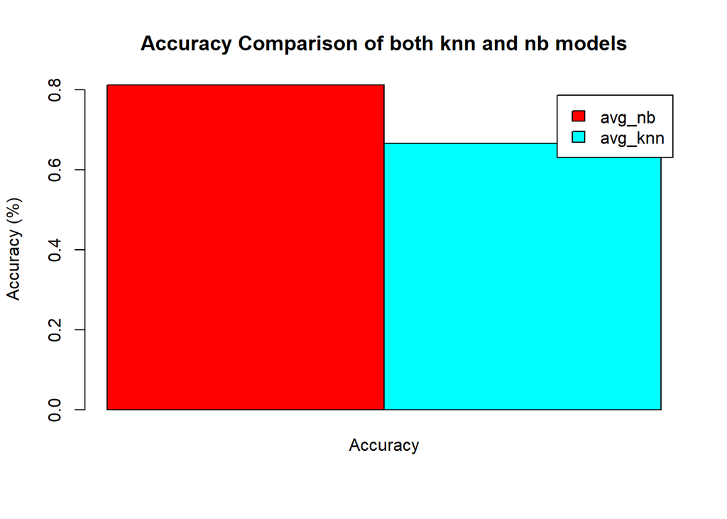

```r
#Getting the barchart plots for average analysis
combined_results <- cbind(data.frame(avg_nb), data.frame(avg_knn))


barplot(t(combined_results[1, ]), beside = TRUE, col = rainbow(2),
        main = "Accuracy Comparison of both knn and nb models",
        ylab = "Accuracy (%)", legend.text = names(combined_results[1, ]))
```

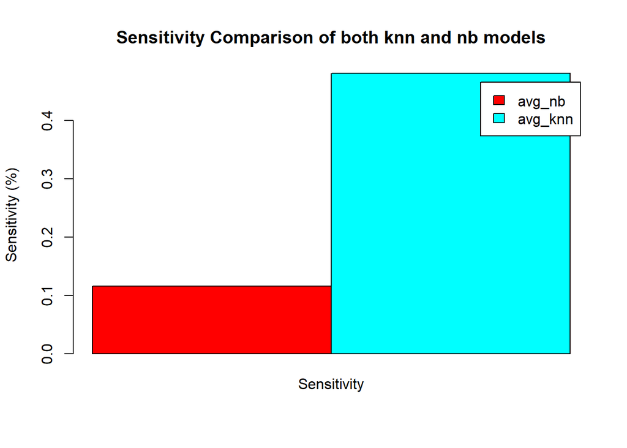

```r
barplot(t(combined_results[2, ]), beside = TRUE, col = rainbow(2),
        main = "Sensitivity Comparison of both knn and nb models",
        ylab = "Sensitivity (%)", legend.text = names(combined_results[2, ]))
```

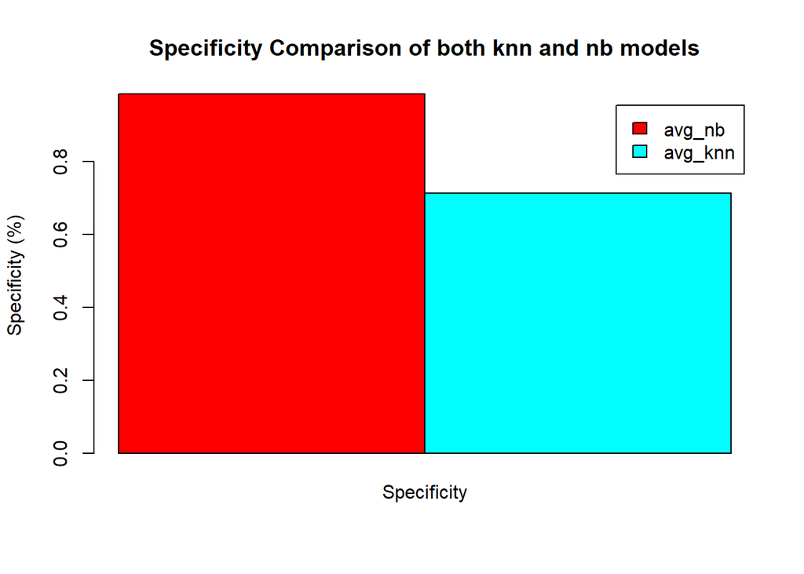

```r
barplot(t(combined_results[3, ]), beside = TRUE, col = rainbow(2),
        main = "Specificity Comparison of both knn and nb models",
        ylab = "Specificity (%)", legend.text = names(combined_results[3, ]))
```

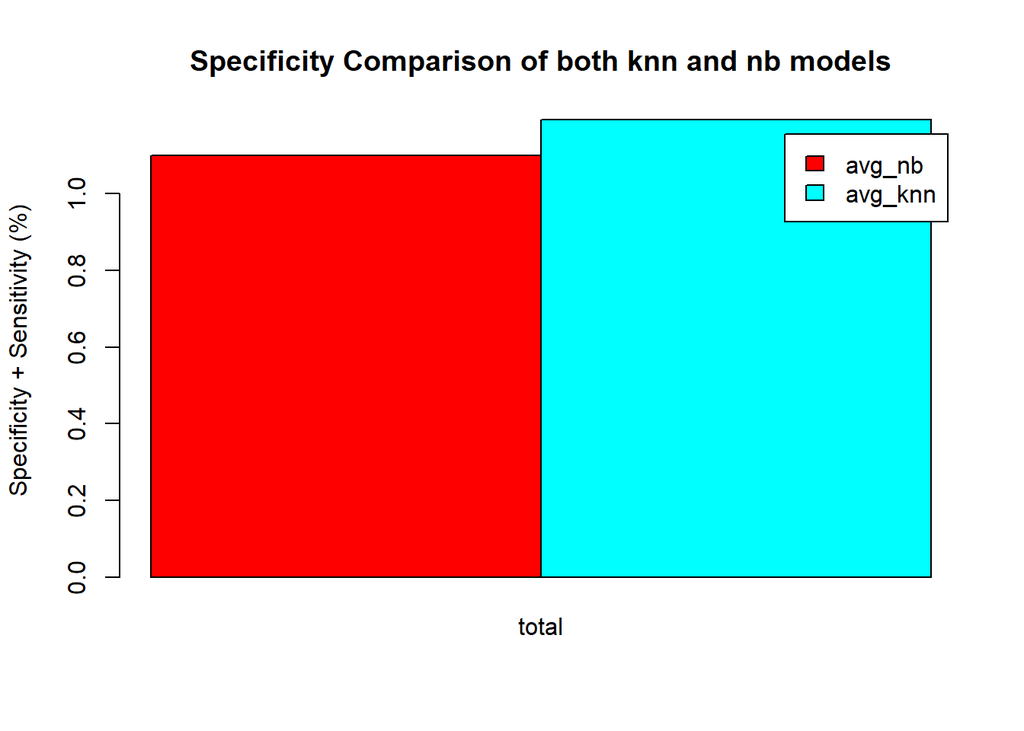

```r
barplot(t(combined_results[4, ]), beside = TRUE, col = rainbow(2),
        main = "Specificity Comparison of both knn and nb models",
        ylab = "Specificity + Sensitivity (%)", legend.text = names(combined_results[4, ]))
```

- Knn has a higher sensitivity and specificity + sensitivity. - Naïve Bayes has higher specificity and accuracy.

## IN CONCLUSION

#### TIPS FOR FRITO LAY

- Try providing more incentives to employees to improve retention rate
- Let the stock options match the amount of years the employees worked.

#### FUTURE WORK

- Try to improve sensitivity values for the classification model.
- Explore other variables that might affect the classification and prediction model.
- Try using other classification techniques to predict my model likeSupport Vector Machine (SVM) or RandomForest